# Some Basics of Descriptive Inference

Steven V. Miller, svmiller.com

5 December 2022

Abstract

This is a lab script for [EH6105](http://eh6105.svmiller.com), a graduate-level quantitative methods class that I teach at Stockholm University. It will not be the most sophisticated R-related write-up of mine—check [my blog](http://svmiller.com/blog) for those—but it should be useful for discussion around the associated R script for the week’s ‘lab’ session.

# R Packages/Data for This Session

You should’ve already installed the R packages for this lab session. `{tidyverse}` will be for all things workflow and `{stevedata}` will be for the toy data sets. Let’s load those libraries now. The order doesn’t really matter here.

```r
library(stevedata)
library(tidyverse)
```

One of you has an issue with `{tidyverse}` because of `{systemfonts}`. These are basically the packages we’ll be using today with that in mind. I won’t load them in this script, but you should “uncomment” (sic) them and load them into your session.

```r
# library(dplyr)
# library(tidyr)
# library(magrittr)
# library(ggplot2)
```

In your R session, please look up the documentation for the data set to get a better idea as to what each variables are. Here’s how I want you to think about this. You the smart researcher know that the `race` column in `gss_spending` is a categorical variable where 1 = white people, 2 = black people, and 3 = people who self-identify with another race. However, your dumb computer and dumb R program don’t know that. They just see numbers. You know the underlying information they communicate. At least, you should know it.

I like to think my toy data sets are well annotated. If you want to read the documentation file for one of my toy data sets, put a `?` before the object name in the console. This should fire up the documentation file in another Rstudio pane (i.e. where the plots typically go).

We’ll be using three toy data sets in this session. The first is American attitudes toward national spending in the General Social Survey (2018). The second is a sample of macroeconomic data from the Penn World Table (from [the previous lab session](http://eh6105.svmiller.com/lab-scripts/intro-r-rstudio.html)). The third data set are attitudes about the justifiability of taking a bribe in the World Values Survey.

```r
# Check out documentation.
?gss_spending
?pwt_sample
?wvs_justifbribe
```

# Identifying Modes and Medians

If you know a variable of interest is discrete (i.e. it only has a finite set of responses), your tools for assessing central tendency are limited. There are two types here: unordered-categorical and ordered-categorical. Unordered-categorical variables are cases where numeric values communicate only differences. While we all learned in elementary school that 2 is greater than 1, we gloss over that it’s also true that 2 does not equal 1. They are distinct from each other. Sometimes, we have a variable where that’s all the underlying information available. Unordered-categorical variables are quite common in the social sciences, even as we don’t necessarily like to acknowledge them as such (because they are information-poor).

## Getting Modes for Unordered-Categorical Variables

For example, the `race` variable in the `gss_spending` is unordered-categorical. We can see from the documentation that 1 = white, 2 = black, and 3 = other. However, we cannot say that 2 (black) is greater than 1 (white) nor can we say that 3 (other) is two greater than 1 (white). Numerically, we know that’s true, but that’s just not the information communicated in this variable. All we can say is that 2 != 1 (which is also true, but not something we really learned in grade school math). Likewise, white != black.

Under those conditions, the most we can do with unordered-categorical variables is to get the mode as an information-poor measure of central tendency. The mode refers to the most commonly occurring value. R doesn’t have a built-in mode function. That’s understandable since modes aren’t very useful information and you can get it through other means. However, we can write a simple function to extract the mode from a variable.

```r
# R doesn't have a built-in mode function. So let's write one.

getmode <- function(v) {
  uniqv <- unique(v)
  uniqv[which.max(tabulate(match(v, uniqv)))]
}

getmode(gss_spending$race)
```

```
## [1] 1
```

```r
gss_spending %>% summarize(mode = getmode(race))
```

```
## # A tibble: 1 × 1
##    mode
##   <dbl>
## 1     1
```

This tells us that there are more white people in the sample than there are people identifying with any other race. This is not surprising. [We already know](https://www.census.gov/quickfacts/fact/table/US/PST045219) that white people are about 75% of the U.S. population (about 60% disentangling out Hispanic [like me] as an ethnicity).

There are more creative means to get the mode and get more information to boot. For example, here’s a “tidy” approach that leans on `group_by()` and `count()`.

```r
gss_spending %>%
  count(race) %>%
  # ^ you could stop here, but let's have more fun.
  # create more information...
  mutate(race_lab = c("White", "Black", "Other"),
         prop = n/sum(n)) %>%
  # creatively arrange the order of columns
  select(race, race_lab, everything())
```

```
## # A tibble: 3 × 4
##    race race_lab     n  prop
##   <dbl> <chr>    <int> <dbl>
## 1     1 White     1693 0.721
## 2     2 Black      385 0.164
## 3     3 Other      270 0.115
```

You could also graph this information. Do note I encourage using a fancier `{ggplot2}` theme (like my `theme_steve()`) in `{stevethemes}`, but this will do for this purpose.

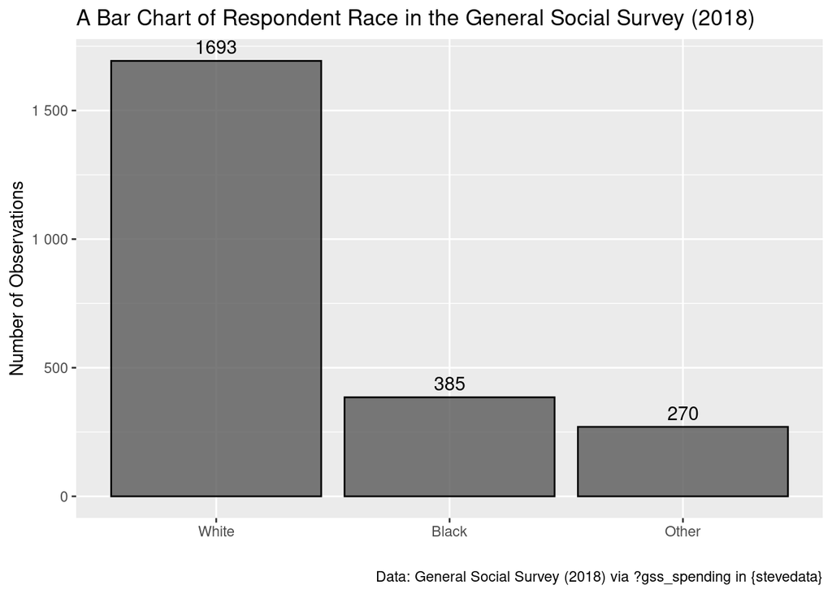

```r
gss_spending %>%
   count(race) %>%
   ggplot(., aes(as.factor(race), n))  +
   geom_bar(color="black", alpha=0.8, stat="identity") +
   scale_y_continuous(labels = scales::comma_format(big.mark = " ")) +
   scale_x_discrete(labels = c("White","Black","Other")) +
   geom_text(aes(label=n), vjust=-.5, colour="black",
             position=position_dodge(.9), size=4) +
   labs(x = "",
        y = "Number of Observations",
        caption = "Data: General Social Survey (2018) via ?gss_spending in {stevedata}",
        title = "A Bar Chart of Respondent Race in the General Social Survey (2018)")
```

## Getting Medians for Ordered-Categorical Variables

The second kind of discrete variable is called “ordered-categorical.” These are variables where increasing (or decreasing) values communicate “more” (or “less”) of some phenomenon being measured, but the distance is inexact or even vague. Logically, ordered-categorical variables say 3 > 1 where unordered-categorical variables say 3 != 1, though these variables do not tell us that 3 is two greater than 1.

Ordered-categorical variables appear in several forms, but perhaps the most common is a Likert item. Likert items give a statement to a respondent and prompt the respondent to respond with their level of agreement. This is often a five-point scale with responses of “strongly disagree” (1), “disagree” (2), “neither agree nor disagree” (3), “agree” (4), and “strongly agree” (5). If someone says they “strongly agree” with the prompt, we can reasonably say they are in more agreement with the prompt than someone who just “agrees”. But how much more are they in agreement with the prompt? We can’t say because the only difference between “strongly agree” and “agree” is a vague magnifier of “strongly”. In other words, 5 > 4, but 5 is not one greater than 4 in this context.

The most precise measure for central tendency for ordered-categorical variables is the median. The median refers to the middlemost value where half of the observations are above it and half of the observations are below it. Fortunately, R has a built-in `median()` function. One caution, though: if you have NAs in the column for which you want the median, the output will return an NA. You can suppress that at your discretion with `na.rm=T`.

Here’s an example of the highest degree obtained by the respondent in the `gss_spending` data frame. Educational attainment is routinely measured like this. Higher values = more educational attainment, which broadly means “more education.” In the `gss_spending` data frame, the `degree` variable assumes values of 0 (did not graduate high school), 1 (completed high school), 2 (completed junior college), 3 (completed four-year bachelor’s equivalent), 4 (graduate degree). This would be the median of that variable.

```r
median(gss_spending$degree, na.rm=T)
```

```
## [1] 1
```

That’s unsurprising the extent to which we know [only about 35% of Americans have at least a four-year college diploma](https://www.census.gov/newsroom/press-releases/2020/educational-attainment.html).

You can also calculate a cumulative percentage to get the same information. The row where the cumulative percentage of responses exceeds 50% is the row that contains the median.

```r
gss_spending %>%
  count(degree) %>%
  mutate(degree_lab = c("Did Not Graduate HS", "High School", "Junior College",
                        "Bachelor Degree", "Graduate Degree"),
         prop = n/sum(n),
         cumperc = cumsum(prop)*100) %>%
  select(degree, degree_lab, everything())
```

```
## # A tibble: 5 × 5
##   degree degree_lab              n   prop cumperc
##    <dbl> <chr>               <int>  <dbl>   <dbl>
## 1      0 Did Not Graduate HS   262 0.112     11.2
## 2      1 High School          1178 0.502     61.3
## 3      2 Junior College        196 0.0835    69.7
## 4      3 Bachelor Degree       465 0.198     89.5
## 5      4 Graduate Degree       247 0.105    100
```